# An overview of GENESPACE

John T. Lovell

Genome Sequencing Center, HudsonAlpha Institute for Biotechnology, Huntsville, AL, USA

jlovell@hudsonalpha.org

10 March 2022

#### Abstract

Details on the functions and output of GENESPACE.

#### Package

GENESPACE 0.9.3

# 1 Prerequisites

See the [readme](https://github.com/jtlovell/GENESPACE) for full installation instructions. In short, the below vignette assumes the following:

1. You are using MacOS or Linux - we have not tested GENESPACE on other OS
2. Orthofinder, MCScanX, R and their dependencies are successfully installed
3. An R interactive session (e.g. Rstudio, command line R) has been opened. To recreate the full run below, R should be opened from a terminal session where OrthoFinder is in the path.
4. The GENESPACE R package and its package dependencies have been installed.

# 2 Example data

First, in R, require the GENESPACE package and make a file path to a directory where you want to put your run. The directory should either be empty or non-existent (GENESPACE will make it for you, assuming that the parent directory exists).

```r
library(GENESPACE)
runwd <- file.path("~/Desktop/testGenespace")
```

To illustrate all steps of the pipeline, lightly subset NCBI-formatted annotations of human/chimpanzee chrs 3-4 and rhesus chr 2 & 5 are provided in the extData of the GENESPACE R package. These data can be added to the above directory with the correct subdirectory structure for GENESPACE via:

```r
make_exampleDataDir(writeDir = runwd)
```

```
## Done! Run GENESPACE with rawGenomeRepo = ~/Desktop/testGenespace/rawGenomes
```

**NOTE** this creates a subdirectory called `/rawGenomes`. For downstream flexibility (e.g. multiple genome versions for one species, metadata or assembly data, etc), the raw genome directory structure follows: `/rawGenomes/$speciesID/$versionID/annotion`.

```r
list.files(runwd, recursive = T, full.names = F)
```

```
## [1] "rawGenomes/chimp/chimp/annotation/chimp_Clint_PTRv2_gene.gff.gz"
## [2] "rawGenomes/chimp/chimp/annotation/chimp_Clint_PTRv2_pep.fa.gz"
## [3] "rawGenomes/human/human/annotation/human_GRCh38.p13_gene.gff.gz"
## [4] "rawGenomes/human/human/annotation/human_GRCh38.p13_pep.fa.gz"
## [5] "rawGenomes/rhesus/rhesus/annotation/rhesus_Mmul_10_gene.gff.gz"
## [6] "rawGenomes/rhesus/rhesus/annotation/rhesus_Mmul_10_pep.fa.gz"
```

When working with your own data, place the raw annotation files in this same directory structure with separate directories for each species, separate subdirectories for each genome version, and the annotation files in a subdirectory called “annotation”.

# 3 Initialize GENESPACE

All elements of GENESPACE require a list of parameters, specified to functions as a GENESPACE parameter list, below `gpar`. This contains paths to files, working directories, program executables the basic parameterization of the run.

The `init_genespace()` function generates this for you. Here are the arguments and what they mean (see the help file for more information):

## 3.1 General set up

- `rawGenomeDir` file path to the directory where the raw genome annotations are stored.
- `genomeIDs` a vector of unique names you want your genomes to be called. Must be alphanumeric, starting with a character.
- `ploidy` integer string specifying ploidy of genome assemblies. This is usually half of the actual ploidy, that is an inbred diploid usually is represented by a haploid genome assembly.
- `path2orthofinder` file path that points to the orthofinder executable. If orthofinder is in the path, specify with “orthofinder”
- `path2mcscanx` file path that points to the mcscanx install directory. This directory must contain the MCScanX_h executable.
- `path2diamond` file path that points to the diamond executable. If orthofinder or diamond is in the path, specify with “diamond”
- `wd` the directory where the GENESPACE run output will be stored.

## 3.2 Paths to raw data (see the directory structure of the example data above)

- `speciesIDs` the subdirectories of `rawGenomeDir` pointing to each `genomeIDs`’s data
- `versionIDs` the subdirectories of `rawGenomeDir/speciesIDs` pointing to the version of each `genomeIDs`’s data.
- `gffString` character string (coercable to a regular expression). File names in the ‘annotation’ subdirectories are screened for this string. If a single, unique file is found, it is returned as the gff source file. Otherwise an error is produced.
- `pepString`character string of length 1, coercable to a regular expression. See `gffString`.

## 3.3 Other optional parameters

- `outgroup` [optional], but if specified, one or more of the `genomeIDs` that will be used in the orthofinder -og run but not in the synteny search.
- `orthofinderMethod` either ‘fast’ or ‘default’
- `diamondMode` character string to match one of the diamond search modes, only used if `orthofinderMethod` = “fast”
- `orthofinderInBlk` should orthofinder be re-run within syntenic regions? Highly recommended for polyploids
- `nCores` the number of parallel processes to run
- `minPepLen` the length of shortest peptides to be analyzed
- `overwrite` should existing directories be overwritten?

## 3.4 Run init_genespace

For the example data, here is how the GENESPACE run setup would look. Simple calls to orthofinder and diamond are here since both of these are in the path from the shell where the R interactive session was originally opened.

```r
gpar <- init_genespace(
  genomeIDs = c("human","chimp","rhesus"),
  speciesIDs = c("human","chimp","rhesus"),
  versionIDs = c("human","chimp","rhesus"),
  outgroup = NULL,
  ploidy = rep(1,3),
  diamondMode = "fast",
  orthofinderMethod = "fast",
  wd = runwd,
  orthofinderInBlk = FALSE,
  overwrite = F,
  verbose = T,
  nCores = 4,
  minPepLen = 50,
  gffString = "gff",
  pepString = "pep",
  path2orthofinder = "orthofinder",
  path2diamond = "diamond",
  path2mcscanx = "~/Documents/comparative_genomics/programs/MCScanX",
  rawGenomeDir = file.path(runwd, "rawGenomes"))
```

```
## Initializing GENESPACE run
##  checking genomeIDs ... PASS (human, chimp, rhesus)
##  checking outgroup ... PASS (no outgroup)
##  checking ploidy ... PASS (1, 1, 1)
##  checking the number of parallel processes ... PASS (4)
##  Verbosity ... PASS (TRUE)
##  minPepLen ... PASS (50)
##  checking working directory ... PASS (~/Desktop/testGenespace)
##  checking parsed gff files ... not found - need to run parse_annotations (etc.)
##  checking parsed peptide files ... not found - need to run parse_annotations (etc.)
## Since some parsed gff and peptide files are missing, checking raw files
##  found raw gff files:
##      human_GRCh38.p13_gene.gff.gz
##      chimp_Clint_PTRv2_gene.gff.gz
##      rhesus_Mmul_10_gene.gff.gz
##  found raw peptide files:
##      human_GRCh38.p13_pep.fa.gz
##      chimp_Clint_PTRv2_pep.fa.gz
##      rhesus_Mmul_10_pep.fa.gz
## Checking dependencies and 3rd party installations
##  MCScanX installation ... PASS (/Users/jlovell/Documents/comparative_genomics/programs/MCScanX/MCScanX_h)
##  Orthofinder installation ... PASS (orthofinder)
##  OrthoFinder method ... PASS - (fast)
##  Orthofinder in block method ... PASS (FALSE)
##  diamond mode ... PASS (--fast)
## GENESPACE run successfully initialized
##  results will be stored in ~/Desktop/testGenespace/results
```

Given that most of these are the defaults, an identical run could be specified as

```r
spec <- c("human","chimp","rhesus")
gpar <- init_genespace(
  genomeIDs = spec,  speciesIDs = spec,  versionIDs = spec, ploidy = rep(1,3),
  diamondMode = "fast", orthofinderMethod = "fast", wd = runwd,
  path2mcscanx = "~/Documents/comparative_genomics/programs/MCScanX",
  rawGenomeDir = file.path(runwd, "rawGenomes"))
```

# 4 Formatting raw data

## 4.1 Downloading raw genome annotations

**NOTE!** If downloading data from NCBI, be sure to use the ‘translated.cds.fa’ peptide annotation files instead of the ‘petide.fa’ files. GENESPACE `parse_ncbi` is built to match the former to the gff and not the latter.

**NOTE!** If downloading from phytozome, or any other data source, it can be benefical to get the ‘primaryTranscriptOnly’, ‘longest’, ‘hightConfidenceOnly’ (or similar) annotation files. In most cases, taking the longest transcript works fine (this is what GENESPACE does), but there are situations where this is not the case.

## 4.2 Motivation

To improve read/write speed, GENESPACE uses a simplified gff3-like text file with a column `id` that exactly matches the peptide fasta header. GENESPACE has built in functions to parse NCBI (`parse_ncbi`) and phytozome (`parse_phytozome`); however, if using non-standard formatted annotations, this can be a tricky step and must be run using `parse_annotations`.

## 4.3 General parse_annotations arguments

- `gsParam` the GENESPACE parameter list, See init_genespace.
- `genomeIDs` the genomeIDs that you want to parse. Sometimes you’ll need to use different parameter specifications for different genomes. Give only the genomes that you’d like to parse for this specific call.
- `overwrite` should existing files be overwritten?
- `troubleshoot` should the headers of the raw and parsed files be printed to help determine how to parameterize the run?

## 4.4 Parsing the gff

The gff file is parsed in three ways:

1. lines are subset to the entry type of interest (e.g. ‘gene’, ‘mRNA’, ‘CDS’, etc). This is specified in `gffEntryType`.
2. the “;” separated field in the 9th column (e.g. ‘ID’, ‘name’, ‘parent’ etc.) is extracted. This is specified in `gffIdColumn`.
3. any superfluous text in the ID field is stripped away. This is specified in `gffStripText` as a regular expression.

## 4.5 Parsing the peptide fasta headers

GENESPACE needs to have the fasta header exactly match the gff gene ID. To facilitate this, there are three parameters to parse the peptide header.

1. `headerEntryIndex` specifies which field in the fasta header contains the gene ID information to match with the gff.
2. `headerSep` is the character that delimits the header fields.
3. `headerStripText` which, like its equivalent in the gff, removes any text taht would make the geneIDs not match the gff.

## 4.6 Parsing the example data

While the example data was originally downloaded from NCBI, much of the NCBI formatting was stripped to make the files smaller. They now can be parsed with the generic `parse_annotations`:

```r
parse_annotations(
  gsParam = gpar,
  gffEntryType = "gene",
  gffIdColumn = "locus",
  gffStripText = "locus=",
  headerEntryIndex = 1,
  headerSep = " ",
  headerStripText = "locus=")
```

```
## Parsing annotation files ...
##  human ...
##      Importing gff ... found 1787 gff entires, and 1787 gene entries
##      Importing fasta ... found 1787 fasta entires
##      1786 gff-peptide matches
##  Done!
##  chimp ...
##      Importing gff ... found 1927 gff entires, and 1927 gene entries
##      Importing fasta ... found 1927 fasta entires
##      1926 gff-peptide matches
##  Done!
##  rhesus ...
##      Importing gff ... found 1906 gff entires, and 1906 gene entries
##      Importing fasta ... found 1906 fasta entires
##      1904 gff-peptide matches
##  Done!
```

If the annotations were directly from NCBI, we would use a simpler specification:

```r
parse_ncbi(gsParam = gpar, overwrite = T)
```

# 5 Run orthofinder

```r
gpar <- run_orthofinder(
  gsParam = gpar)
```

```
## Synteny Parameters have not been set! Setting to defaults
##  Running 'draft' a.k.a 'fast' genespace orthofinder method
##  ############################################################
##  ***NOTE***
##  This method should only be used for:
##      (1) closely related diploid species,
##      (2) visualization/genome QC purposes, or
##      (3) inferring orthogroups WITHIN syntenic regions
##  ############################################################
##      Running 1/6 (chimp vs. chimp)
##      Running 2/6 (chimp vs. rhesus)
##      Running 3/6 (rhesus vs. rhesus)
##      Running 4/6 (chimp vs. human)
##      Running 5/6 (rhesus vs. human)
##      Running 6/6 (human vs. human)
##      Done!
##  Inverting intergenomic files ... Done!
##  Running orthofinder -og on pre-computed blast:
##
##
##  OrthoFinder version 2.5.4 Copyright (C) 2014 David Emms
##
##  2022-03-10 19:39:53 : Starting OrthoFinder 2.5.4
##  4 thread(s) for highly parallel tasks (BLAST searches etc.)
##  1 thread(s) for OrthoFinder algorithm
##
##  Checking required programs are installed
##  ----------------------------------------
##  Test can run "mcl -h" - ok
##  Using previously calculated BLAST results in /Users/jlovell/Desktop/testGenespace/orthofinder/
##
##  Running OrthoFinder algorithm
##  -----------------------------
##  2022-03-10 19:39:53 : Initial processing of each species
##  2022-03-10 19:39:54 : Initial processing of species 0 complete
##  2022-03-10 19:39:54 : Initial processing of species 1 complete
##  2022-03-10 19:39:54 : Initial processing of species 2 complete
##  2022-03-10 19:39:57 : Connected putative homologues
##  2022-03-10 19:39:57 : Written final scores for species 0 to graph file
##  2022-03-10 19:39:57 : Written final scores for species 1 to graph file
##  2022-03-10 19:39:58 : Written final scores for species 2 to graph file
##  2022-03-10 19:39:58 : Ran MCL
##
##  Writing orthogroups to file
##  ---------------------------
##  OrthoFinder assigned 5413 genes (96.4% of total) to 1756 orthogroups. Fifty percent of all genes were in orthogroups with 3 or more genes (G50 was 3) and were contained in the largest 864 orthogroups (O50 was 864). There were 1673 orthogroups with all species present and 1605 of these consisted …
##
##  2022-03-10 19:39:59 : Done orthogroups
##
##  Results:
##      /Users/jlovell/Desktop/testGenespace/orthofinder/OrthoFinder/Results_Mar10/
##
##  CITATION:
##   When publishing work that uses OrthoFinder please cite:
##   Emms D.M. & Kelly S. (2019), Genome Biology 20:238
##
##   If you use the species tree in your work then please also cite:
##   Emms D.M. & Kelly S. (2017), MBE 34(12): 3267-3278
##   Emms D.M. & Kelly S. (2018), bioRxiv https://doi.org/10.1101/267914
```

The orthofinder run is stored in the `/orthofinder` subdirectory of the main working directory. GENESPACE has convienence functions to read and parse the orthologs, orthogroups and blast hits in case you want to explore these results directly.

# 6 Set synteny parameters

Synteny has a lot of parameters that allow you to fine-tune the synteny search. For most cases the defaults should be fine, but in some cases (e.g. very diverged genomes or studying ancient whole-genome duplicates) it will be crucial to manipulate these. If you do not run `set_syntenyParams` prior to `synteny` (see below), the defaults are used unless you specify them in the call. For example, if you want to only find larger blocks, you could run `synteny(gsParam, blkSize = 20)`. However, if you have previously run `synteny` you will need to separately re-specify your parameters with `set_syntenyParams`, since `synteny` will respect the previously defined parameters in the gsParam list.

## 6.1 Main synteny parameters

Below are a list of the synteny parameters. For many there is a “second” option. This is the parameter specification for homeologs (duplicates within polyploid genomes) or paralogs after masking the orthologous regions.

- `synBuff`: the gene-rank order radius surround an anchor hit to include nearby hits that are in the buffer region.
- `blkSize`; : the minimum size of a colinear run of genes for that region to be called a syntenic block. This parameter is used for both `dbscan(min.pts)` and `MCScanX_h -s` specification.
- `nGaps`; : the `MCScanX_h -m` parameter; the number of gaps allowed for a collinear region to be called a block.
- `synBuff`; : the gene-rank order position around syntenic anchors within which hits are considered within a syntenic region and retained in the pan-genome db.
- `onlyOgAnchors`; : logical, should only orthogroup-constrained hits be considered as candidates for syntenic anchors? This should almost always be TRUE, unless the genomes you are studying are very diverged.

## 6.2 Other synteny parameters

- `nSecondHits`: the number of secondary hits, after accounting for ploidy. This is usually set to 0, unless you wish to test for paralogous regions. Any parameters below ending in “Second” are passed to these secondary hits.
- `synBuffSecond`, `blkSizeSecond`, `nGapsSecond`, `synBuffSecond`, `onlyOgAnchorsSecond` same as above but for the secondary hits. Allows the user to relax thresholds for highly-diverged paralogs.
- `arrayBuffer` the maximum gap between adjacent genes in the same orthogroup on a chromosome for them to be considered an array.

```r
gpar <- set_syntenyParams(gsParam = gpar)
```

To see what these look like, you can print the `gpar$params$synteny` data.table …

| genome1 | genome2 | u | ploidy1 | ploidy2 | ofID1 | ofID2 | nGenes1 | nGenes2 | nhits1 | nhits2 | query | target | runBlast | mirrorBlast | nSecondHits1 | nSecondHits2 | onlyOgAnchors | onlyOgAnchorsSecond | blkSize | blkSizeSecond | nGaps | nGapsSecond | synBuff | synBuffSecond | selfRegionMask | nSecondHits |
| --- | --- | --- | --- | --- | --- | --- | --- | --- | --- | --- | --- | --- | --- | --- | --- | --- | --- | --- | --- | --- | --- | --- | --- | --- | --- | --- |
| chimp | chimp | chimp chimp | 1 | 1 | 0 | 0 | 1926 | 1926 | 1 | 1 | chimp | chimp | TRUE | FALSE | 0 | 0 | TRUE | FALSE | 5 | 5 | 5 | 20 | 100 | 100 | 500 | 0 |
| chimp | rhesus | chimp rhesus | 1 | 1 | 0 | 2 | 1926 | 1904 | 1 | 1 | chimp | rhesus | TRUE | FALSE | 0 | 0 | TRUE | FALSE | 5 | 5 | 5 | 20 | 100 | 100 | 500 | 0 |
| rhesus | chimp | rhesus chimp | 1 | 1 | 2 | 0 | 1904 | 1926 | 1 | 1 | chimp | rhesus | FALSE | TRUE | 0 | 0 | TRUE | FALSE | 5 | 5 | 5 | 20 | 100 | 100 | 500 | 0 |
| rhesus | rhesus | rhesus rhesus | 1 | 1 | 2 | 2 | 1904 | 1904 | 1 | 1 | rhesus | rhesus | TRUE | FALSE | 0 | 0 | TRUE | FALSE | 5 | 5 | 5 | 20 | 100 | 100 | 500 | 0 |
| chimp | human | chimp human | 1 | 1 | 0 | 1 | 1926 | 1786 | 1 | 1 | chimp | human | TRUE | FALSE | 0 | 0 | TRUE | FALSE | 5 | 5 | 5 | 20 | 100 | 100 | 500 | 0 |
| human | chimp | human chimp | 1 | 1 | 1 | 0 | 1786 | 1926 | 1 | 1 | chimp | human | FALSE | TRUE | 0 | 0 | TRUE | FALSE | 5 | 5 | 5 | 20 | 100 | 100 | 500 | 0 |
| human | rhesus | human rhesus | 1 | 1 | 1 | 2 | 1786 | 1904 | 1 | 1 | rhesus | human | FALSE | TRUE | 0 | 0 | TRUE | FALSE | 5 | 5 | 5 | 20 | 100 | 100 | 500 | 0 |
| rhesus | human | rhesus human | 1 | 1 | 2 | 1 | 1904 | 1786 | 1 | 1 | rhesus | human | TRUE | FALSE | 0 | 0 | TRUE | FALSE | 5 | 5 | 5 | 20 | 100 | 100 | 500 | 0 |
| human | human | human human | 1 | 1 | 1 | 1 | 1786 | 1786 | 1 | 1 | human | human | TRUE | FALSE | 0 | 0 | TRUE | FALSE | 5 | 5 | 5 | 20 | 100 | 100 | 500 | 0 |

# 7 Calculate synteny

## 7.1 Main synteny pipeline steps

The main engine of GENESPACE is `synteny`. This is a complex function that parses blast hits into syntenic regions and blocks. For each unique pair of genomes, `synteny` conducts six main steps.

1. Read the gffs, combine into a single object and add the global orthogroup ID for each gene. Genes within `arrayBuffer` from eachother in the same orthogroup are members of the same array. For each array, an “arrayRep” gene is chosen as the model closest to the median position of the array.
2. read and subset the blast file, retaining the unique hit with the highest score. Also adds required information including orthofinder orthogroup ID, genome position (chromosome, bp, gene rank order), score-rank (the blast hit is ranked by highest to lowest scoring for each gene).
3. subsets out potential anchor hits. These only hits where both query and target genes are array representatives, [if onlyOgAnchors = TRUE] both query and target genes must be in the same orthogroup, and the top n scoring hits, where n is informed by the ploidy of the query and target genomes.
4. finds anchor hits by running MCScanX_h (passing `nGaps` and `blkSize` parameters) on potential anchors, pulling all hits within a fixed radius (`synBuff`) of the initial hits, re-ranking the order of these hits and re-running MCScanX_h, and finally clustering the anchor hits with a dbscan and dropping any blocks smaller than the `blkSize`. Syntenic block coordinates are extracted from these anchor hits. All hits, regardless of orthogroup identity are then classified as “isAnchor” and “inBuffer” - within the `synBuff` of an anchor hit. The orthogroup calls are then split into “synOGs”, so that all edges in each synOG is connected by genes within syntenic regions.
5. If `nSecondaryHits > 0` or the pairwise blast results are intragenomic for a genome with ploidy > 1, the self (if polyploid intragenomic) or anchor hits are masked and step 3 is re-run.
6. If `orthofinderInBlk = TRUE`, for each syntenic region, all inBuffer hits are fed into orthofinder (assuming there are enough for it to be run, see below). This produces an “inBlkOG”, which replaces the synOG as the primary orthogroup ID and step 3 is re-run.

## 7.2 Running synteny

```r
gpar <- synteny(gsParam = gpar)
```

```
## Indexing location of orthofinder results ... Done!
## Parsing the gff files ...
##  Reading the gffs and adding orthofinder IDs ... Done!
##  Found 1959 global OGs for 5616 genes
##  QC-ing genome to ensure chromosomes/scaffolds are big enough...
##              Genome: n. chrs PASS/FAIL, n. genes PASS/FAIL, n. OGs PASS/FAIL
##      chimp: 2/0, 1926/0, 1850/0
##      human: 2/0, 1786/0, 1718/0
##      rhesus: 2/0, 1904/0, 1839/0
##  All look good!
##  Defining collinear orthogroup arrays ...
##  Found the following counts of arrays / genome:
##      chimp: 97 genes in 35 collinear arrays
##      human: 96 genes in 31 collinear arrays
##      rhesus: 92 genes in 35 collinear arrays
## Pulling synteny for 6 unique pairwise combinations of genomes
##  Running 2 chunks of up to 4 combinations each:
##  Chunk 1 / 2 (19:40:02) ... Done!
##  chimp   -rhesus  : 4365 (tot), 2771/7 (reg), 1761/14 (blk)
##  chimp   -human   : 4255 (tot), 2785/4 (reg), 1760/5 (blk)
##  rhesus  -human   : 4179 (tot), 2647/9 (reg), 1728/12 (blk)
##  chimp   -chimp   : 4808 (tot), 3032/2 (reg), 1926/2 (blk)
##  Chunk 2 / 2 (19:40:06) ... Done!
##  rhesus  -rhesus  : 4468 (tot), 2854/2 (reg), 1904/2 (blk)
##  human   -human   : 4524 (tot), 3086/2 (reg), 1786/2 (blk)
## Defining synteny-constrained orthogroups ...
##  Found 2004 synteny-split OGs for 5616 genes
## Found 2004 OGs across 5616 genes. gff3-like text file written to:
##  ~/Desktop/testGenespace/results/gffWithOgs.txt.gz
## Calculating syntenic block breakpoints ...
##  Found 68 blocks. Text file written to:
##  ~/Desktop/testGenespace/results/syntenicBlocks.txt.gz:
```

This function populates the results directory (~/Desktop/testGenespace/results) directory with dotplots and annotated blast hits. Its always worth looking at the dotplots to make sure that your synteny parameterization caputured the expected patterns of synteny.

# 8 Riparian plots

In many cases, the most important output from GENESPACE is just the reference chromosome-informed synteny plot, which we call the ‘riparian plot’. The functions to build this, `plot_riparian` (legacy) and `plot_riparianHits` (current), build upon similar river plots from other software, by phasing and splitting all blocks by their syntenic relationship with a single reference genome; thereby allowing a view of how one chromosome is syntenic across a large network. In simple systems where all genomes are haploid, `plot_riparian` will perform adequately; however, this will be phased out in later releases in favor of `plot_riparianHits`, which is slower, but more accurately infers the relationships between all chromosomes to a reference genome.

## 8.1 Genome-wide synteny graphs

GENESPACE visualizes multi-species synteny with a ‘riparian’ plot. The default specification does the following:

- orders chromosomes by maximum synteny (`reorderChrs = TRUE`) to a reference genome
- colors blocks by synteny to the reference chromosome (`refChrCols = colors`)
- uses gene rank order (`useOrder = TRUE`) instead of physical basepair position
- plots small syntenic blocks (`useBlks = TRUE`), instead of larger syntenic regions

There are a large number of parameters to allow custom plotting (we won’t go into all of them here, but see `?plot_riparianHits` for details).

```
##  Reading hits ... Done!
##  Generating plot coordinates ... Done!
##  Rendering plot ...
```

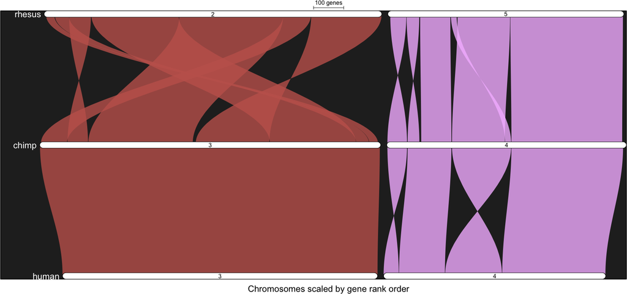

```
## Done!
```

```r
plot_riparianHits(gpar)
```

## 8.2 Customizing the plot

You can easily alter the order of genomes and which genome is the reference. Also using this as an opportunity to show some other features:

- `labelTheseGenomes` labeling only two genomes
- `invertTheseChrs` inverting a chromosome that is more syntenic if reversed
- `refChrCols` specifying custom colors
- `genomeIDs` re-ordering the genomes on the y-axis
- `refGenome` using synteny to chimp as the chromosome ordering anchor
- `gapProp` decreasing the spacing between chromosomes
- `blackBg` turning off the black background
- `returnSourceData` returns a list with the source data for the plot

```
##  Reading hits ... Done!
##  Generating plot coordinates ... Done!
##  Rendering plot ...
```

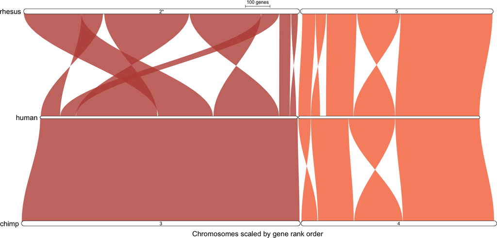

```
## Done!
```

```r
ripSouceDat <- plot_riparianHits(
  gpar,
  refGenome = "chimp",
  invertTheseChrs = data.frame(genome = "rhesus", chr = 2),
  genomeIDs = c("chimp", "human", "rhesus"),
  labelTheseGenomes = c("chimp", "rhesus"),
  gapProp = .001,
  refChrCols = c("#BC4F43", "#F67243"),
  blackBg = FALSE,
  returnSourceData = T,
  verbose = F)
```

## 8.3 Plotting regions of interest

We can also plot a few regions. Lets make 4 regions to highlight (`regs`) and plot them. This object, which is passed to `onlyTheseRegions` must have at least two columns (“genome”, “chr”). If only these columns are specified, the colors are given from a standard palette and the entire chromosomes are highlighted. If “start” and “end” are given, then only these regions for these chromosomes are shown. The “col” column can be given any set of characters or numbers that R can interpret as colors.

```
##  Reading hits ... Done!
##  Building database of hits in 4 regions ... Done!
##  Generating plot coordinates ... Done!
##  Rendering plot ...
```

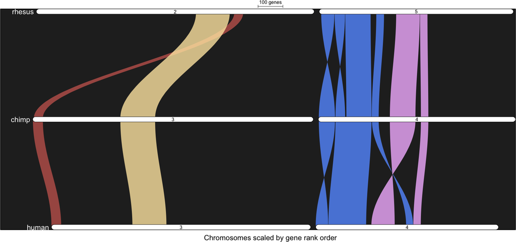

```
## Done!
```

```r
regs <- data.frame(
  genome = c("human", "human", "chimp", "rhesus"),
  chr = c(3, 3, 4, 5),
  start = c(0, 50e6, 0, 60e6),
  end = c(10e6, 70e6, 50e6, 90e6),
  cols = c("pink", "gold", "cyan", "dodgerblue"))

plot_riparianHits(
  gpar,
  onlyTheseRegions = regs)
```

The default behavior is to show the entire genome, but, if you only want to show one chromosome, it can be specified as follows. In this case, `excludeNoRegChr = TRUE` means that any chromosomes with no syntenic links to the regions specified are excluded.

```
##  Reading hits ... Done!
##  Building database of hits in 2 regions ... Done!
##  Generating plot coordinates ... Done!
##  Rendering plot ...
```

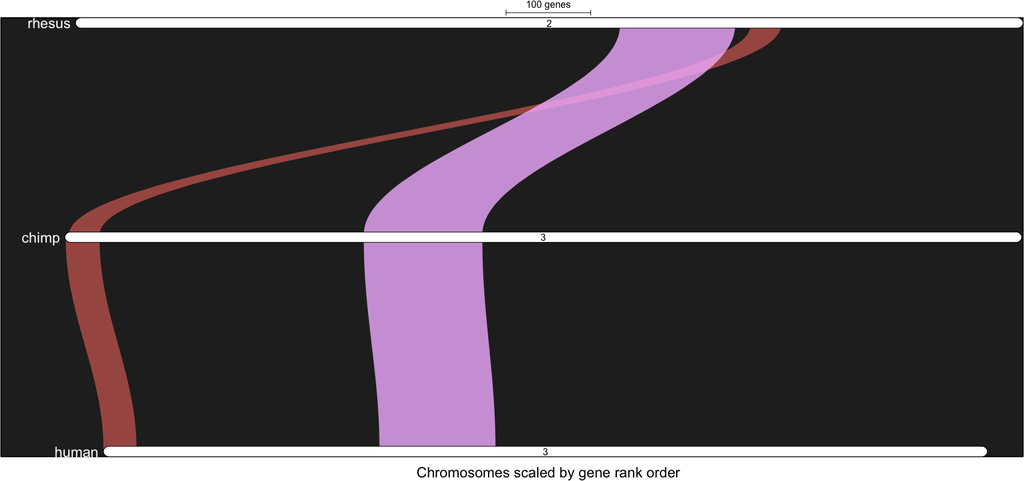

```
## Done!
```

```r
regs2 <- data.frame(
  genome = c("human", "human"),
  chr = c(3, 3),
  start = c(0, 50e6),
  end = c(10e6, 70e6),
  cols = c("pink", "gold"))

plot_riparianHits(
  gpar,
  onlyTheseRegions = regs2,
  excludeNoRegChr = T)
```

## 8.4 Overlaying multiple plots

Lastly, you may want to overlay regions of interest onto a genome-wide run. This can be accomplished with some care using the `annotatePlot` and `add2plot` arguments as follows. Here, we are coloring the original plot with light grey braids so that it forms a background, then overlaying the regions from above onto the original plot and only annotating this second plot.

```r
plot_riparianHits(
  gpar,
  refChrCols = "grey80",
  annotatePlot = F)
```

```
##  Reading hits ... Done!
##  Generating plot coordinates ... Done!
##  Rendering plot ...
```

```
## Done!
```

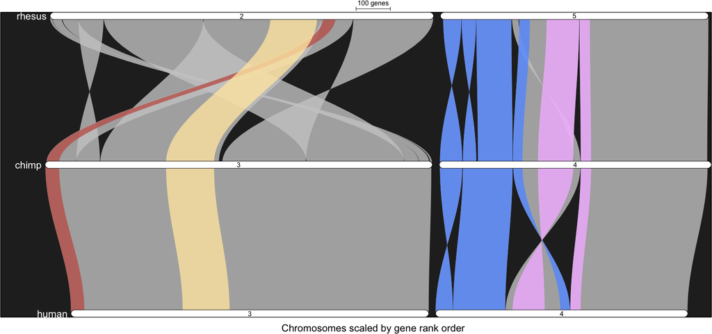

```
##  Reading hits ... Done!
##  Building database of hits in 4 regions ... Done!
##  Generating plot coordinates ... Done!
##  Rendering plot ... Done!
```

```r
plot_riparianHits(
  gpar,
  onlyTheseRegions = regs,
  add2plot = T)
```

# 9 Build a pangenome annotation

The main output of GENESPACE is a synteny-anchored pan-genome annotation, where every unique synteny-constrained orthogroup is placed in a position on the reference genome gene order. This is constructed by `pangenome`.

## 9.1 Pangenome construction methods

The pan-genome annotation is constructed in seven steps:

1. The gff is queried, extracting only array representative genes in the specified reference genome. This becomes the “reference scaffold” for the pan-genome annotation.
2. Hits for all genomes against the reference are read in and culled to only hits where the reference genome geneID is in the reference scaffold and both the query and target are in the same syntenic orthogroup. Each of these subgraphs are added to the reference scaffold, producing a reference pan-genome.
3. The syntenic position for all genes are interpolated against the reference using only syntenic anchor hits in the reference pan-genome.
4. Syntenic orthogroups that do not contain a reference gene are added to the pan-genome iteratively, placed in the most common location(s) from the interpolated positions. This is the pan-genome annotation - all entries are flagged as `isDirectSyn = TRUE`.
5. Genes that are members of syntenic orthogroups, but not represented in pan-genome annotation are added and flagged as `isSynOgOnly = TRUE`.
6. Genes that are members of arrays, but not the representative are added in and flagged as `isArrayRep = FALSE`
7. All orthologs from the original orthofinder run are parsed and those that are not captured in the syntenic pan-genome annotation are added and flagged as `isNSOrtho = TRUE`

## 9.2 Calling pangenome

```r
pg <- pangenome(gpar)
```

```
## Building reference-anchored scaffold against human
##  n. ref positions = 1721
##  Reading in hits against human ... found 5095
##  Interpolating positions ... n. genes mapped: 1x = 3682, 2+x = 0, 0x = 1750
##  Forming ref.-anchored db ... found 5047 genes for 1721 placements
## Completing the pan-genome annotation ...
##  Adding non-anchor entries ... found 47 genes and 38 placements
##  Checking missing direct ref. syn. OGs ... found 5 genes and 5 placements
##  Adding indirect syn. OGs ... found 0 genes and 0 placements
##  Adding syn. OGs without ref. anchor ... found 310 genes and 265 placements
##  Adding missing genes by synOG identity ... found 0 genes and 0 placements
## Annotating and formatting pan-genome
##  Adding non-anchor entries ... found 178 genes and 57 placements
##  No orthologue file available. Will ignore
##  Writing pangenome to results/human_pangenomeDB.txt.gz
##  Returning wide-format with only syntenic array reps
##  Done!
```

## 9.3 Pangenome text file output

For each pan-genome, constructed against a reference, GENESPACE writes a file: `/results/[refgenome]_pangenome.txt.gz`. This is the source data that can be manipulated programatically to extract your regions of interest. Future GENESPACE releases will have auxilary functions that let the user access the pan-genome by rules (e.g. contains these genes, in these regions etc.). For now, we’ll leave this work to scripting by the user.

The text file contains the following fields:

- [“pgChr”, “pgOrd”, “pgID”, “og”] … these are unique pan-genome entry identifiers. “pgChr” and “pgOrd” are the inferred chromosome and gene rank order in the reference genome used in the pangenome(…, refGenome = "“) call. If you didn’t specify a refGenome, it will just be the first genomeID you specified in init_genespace().”pgID" is a unique identifier for each entry. “og” is the orthogroup that the anchor of the entry belongs to.
- [“ofID”, “genome”, “id”] … these are the IDs and metadata for each gene. “ofID” is the orthofinder internal ID and crucial for mapping against the synHits and gff, but mostly just used internally. “id” is the geneID in the gff. “genome” is the genome where that gene resides.
- [isDirectSyn, isSynOgOnly, isArrayRep, isNSOrtho] … see pipeline description above

## 9.4 Pangenome R object output

`pangenome` also returns an R object, which is a data.table with the first three metadata positional information columns as the source text file. The follow columns are labeled by the genomeIDs and give gene members for each pan-genome entry (row). Each entry is a list of the geneIDs, which appears as a “,” separated vector when printed in R. If written to file using `fwrite`, the commas will become “|” separated, per data.table specification. Non-rep array members are flagged with a “+” following the geneID; non-syntenic orthologs are flagged with "*".

**NOTE!** If the run was accomplished with `orthofinderMethod = "fast"`, non-syntenic orthologs will NOT be reported, since this method does not permit ortholog inference by orthofinder.

# 10 General considerations